# final_project

Vaibhav Bhatt

12/12/2021

```r
# business problem
```

The purpose of the project is to build a model that correctly identifies the species of the iris flower based on the measurement of the flower’s petal and sepal. The dataset contains 150 observations of iris flowers. There are four columns of measurements of the flowers in centimeters. The fifth column is the species of the flower observed. All observed flowers belong to one of three species

```r
#loading data
data(iris)
dataset <- iris
```

The dataset is available in R, therefore as per the code above, I retrieved it directly from R. However, the dataset is also available online in .data format that needs to be converted into csv format first and then can be uploaded into R using read_csv.

Below is the description of the training dataset::

```r
# dimensions of dataset
dim(dataset)
```

```
## [1] 120   5
```

Dataset has 120 rows and 5 columns

```r
sapply(dataset, class)
```

```
## Sepal.Length  Sepal.Width Petal.Length  Petal.Width      Species
##    "numeric"    "numeric"    "numeric"    "numeric"     "factor"
```

We can see that all the input features are numeric and the output “species” is a factor

```r
head(dataset)
```

```
##   Sepal.Length Sepal.Width Petal.Length Petal.Width Species
## 1          5.1         3.5          1.4         0.2  setosa
## 2          4.9         3.0          1.4         0.2  setosa
## 3          4.7         3.2          1.3         0.2  setosa
## 6          5.4         3.9          1.7         0.4  setosa
## 7          4.6         3.4          1.4         0.3  setosa
## 8          5.0         3.4          1.5         0.2  setosa
```

Here is the first few rows of the dataset

```r
levels(dataset$Species)
```

```
## [1] "setosa"     "versicolor" "virginica"
```

output variable is a “factor” and this code chunk explains different categories of output. This is multiclassification problem i.e our model needs to predict the output out of many possible options

```r
percentage <- prop.table(table(dataset$Species)) * 100
cbind(freq=table(dataset$Species), percentage=percentage)
```

```
##            freq percentage
## setosa       40   33.33333
## versicolor   40   33.33333
## virginica    40   33.33333
```

We can see that our training dataset has equal number of input variables for each expected output

```r
summary(dataset)
```

```
##   Sepal.Length    Sepal.Width    Petal.Length    Petal.Width          Species
##  Min.   :4.400   Min.   :2.00   Min.   :1.000   Min.   :0.100   setosa    :40
##  1st Qu.:5.100   1st Qu.:2.80   1st Qu.:1.600   1st Qu.:0.300   versicolor:40
##  Median :5.750   Median :3.00   Median :4.250   Median :1.300   virginica :40
##  Mean   :5.848   Mean   :3.08   Mean   :3.754   Mean   :1.197
##  3rd Qu.:6.400   3rd Qu.:3.40   3rd Qu.:5.100   3rd Qu.:1.800
##  Max.   :7.900   Max.   :4.40   Max.   :6.900   Max.   :2.500
```

One interesting observation here is that all the instances are in the same range and in the same unit. In a real world dataset, we may need to look these values carefully as data preprocessing may be needed if the input variables are not in the same unit or may have anomalies.

Below are the plots:

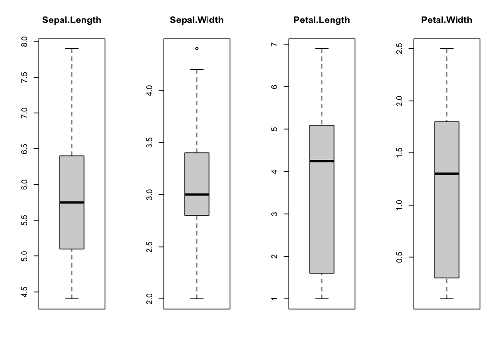

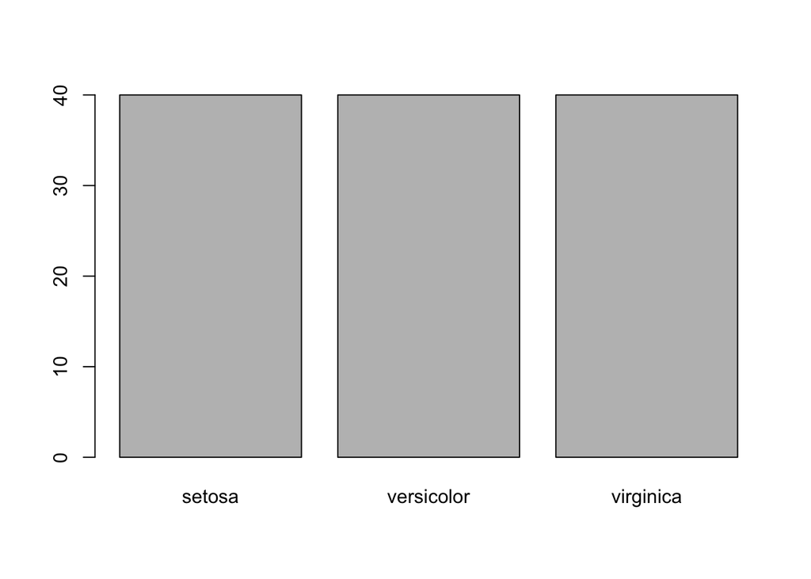

plot for every feature:

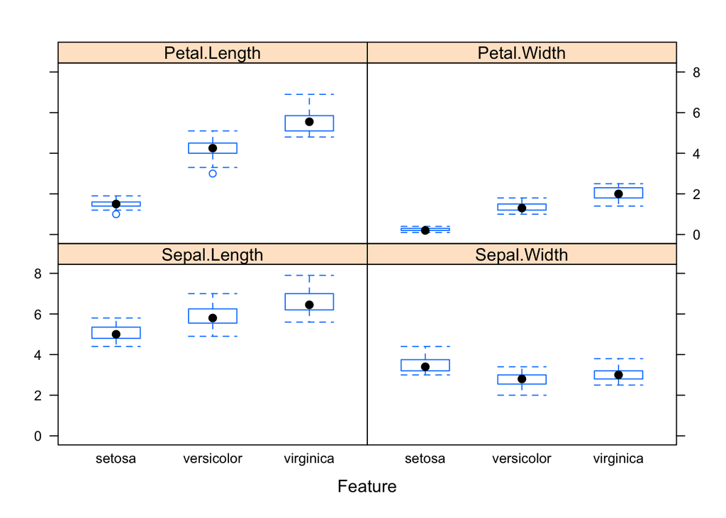

Density plot:

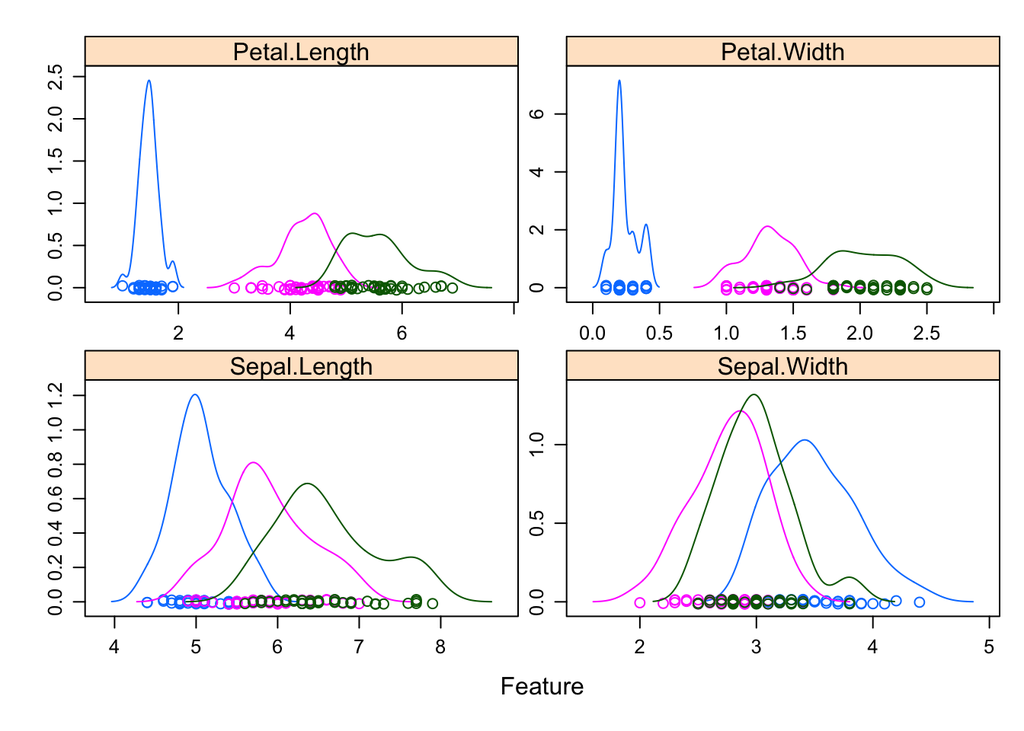